# New York Airbnb Price Prediction 2019

Ofer Mansour, Jacky Ho, Anand Vemparala

# Summary

In this project, our team attempted to predict Airbnb prices in New York by testing several tree-based algorithms and finding the best performing model. The models used in this project were: Random Forest, XGBoost, LightGBM and an average ensembling of the three algorithms, and evaluated by Mean Absolute Error. The average ensembling of Random Forest, XGBoost and LightGBM was the best performing model with a Mean Absolute Error of $63.94.

# Introduction

We aim to investigate what would be the appropriate or comparable price for a future Airbnb listing in New York in 2020, given the same set of listing features from the dataset. New York is one of the most visited cities in the world, with a predicted 67 million tourists visiting in 2019 (Mcgeehan 2019b) and 65 million tourists (Mcgeehan 2019a) visiting in 2018. With Airbnb’s popularity continuing to rise and its disruption of the hotel industry, more people are staying in Airbnb’s, as 500 million stays in an Airbnb have occurred since 2008 (Sherwood 2019), the company’s founding. With the popularity of both New York as a tourist attraction and Airbnb, being able to predict the price of an Airbnb in New York, given the same set of listing features from the dataset, would be extremely useful. An accurate and reasonable price prediction for a listing would be helpful for New York hosts, especially new hosts, to set their prices correctly.

# Data

The dataset used in this project is about Airbnb listings in New York in 2019. The Airbnb listing data is from[Inside Airbnb](http://insideairbnb.com/get-the-data.html)(“Get the Data - Inside Airbnb. Adding Data to the Debate.” n.d.), which is compiled from Airbnb’s website. Each of the 48,895 rows represents an Airbnb listing, which includes several features, such as the price of the listing, neighbourhood, room type and the number of reviews.

# EDA

Variables:

- **id:** Integer representing listing identification number.
- **name:** The title of the listing.
- **availability_365:** The number of days in the year that the listing is available to book.
- **calculated_host_listings_count:** The total number of listings the host of the listing has.
- **host_id:** Integer representing the host’s identification number.
- **host_name:** First name(s) of host(s).
- **latitude:** The latitude of location of listing.
- **longitude:** The longitude of location of listing.
- **minimum_nights:** The minimum nights a user must book the listing.
- **neighbourhood:** The neighbourhood the listing is in.
- **neighbourhood_group:** The borough the listing is in. (The 5 boroughs of New York are Brooklyn, Manhattan, the Bronx, Staten Island and Queens).
- **number_of_reviews:** The number of reviews the listing has.
- **price (response variable):** The per night price of the listing.
- **reviews_per_month:** The number of reviews the listing has per month.
- **room_type:** The type of room of the listing. (The 3 options are: Entire home/apartment, Private room and Shared room).
- **last_review:** The date of the last review posted of the listing.

We dropped ‘id’,‘name’, ‘host_id’, ‘host_name’,‘last_review’ as they do not provide any insight on the price of a listing. To standardize the data, we imputed values by replacing NaNs with zeros wherever required.

To understand how strongly the remaining features are correlated to the price of a listing, we generated a correlation plot for all numerical features.

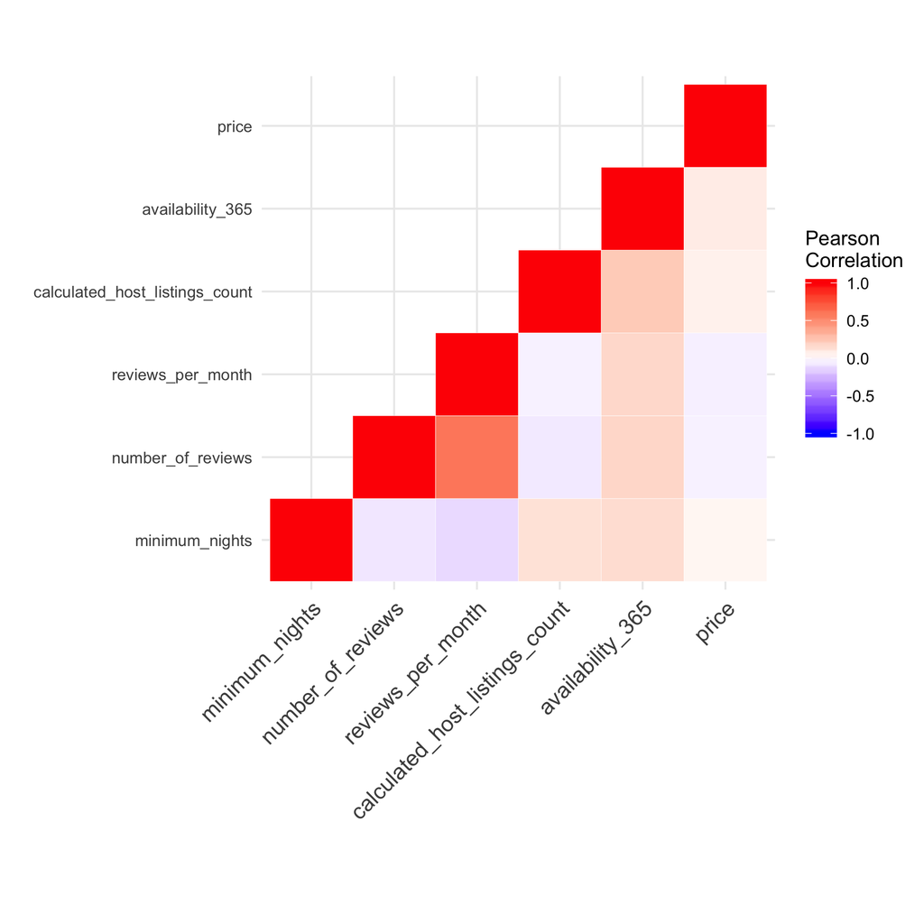

Figure 1. Correlation and distribution plots for numerical features

We observe that no individual predictor by itself is highly correlated to price.

We look at the distribution of our target variable price to get a general sense of the prices in all neighbourhoods of New York. There is an outlier that stands at $10,000. Other than this outlier, all prices are mostly less than $1000, with an average of $152 per night.

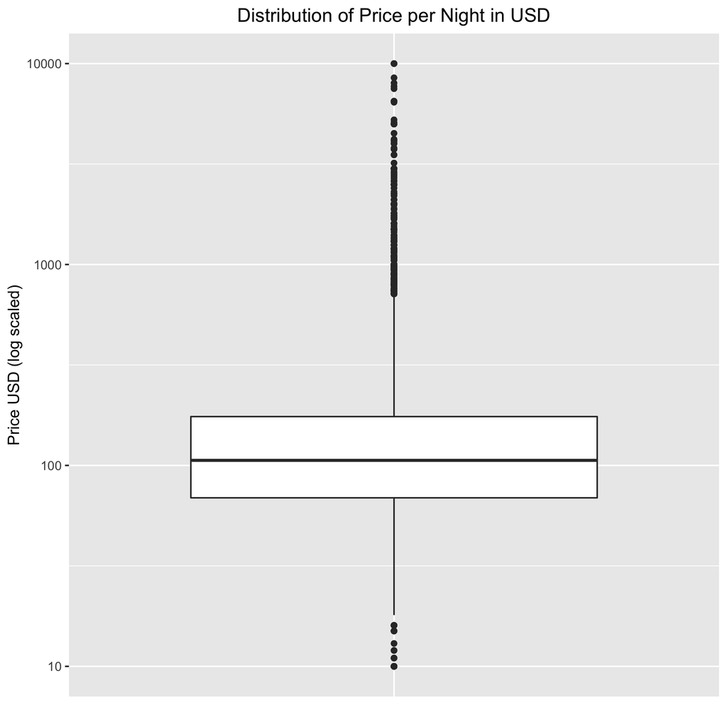

Figure 2. Distribution of New York Airbnb prices per night in 2019

To understand the categorical features, we grouped the prices per night of the Airbnb listings based on the neighbourhood and the room type.

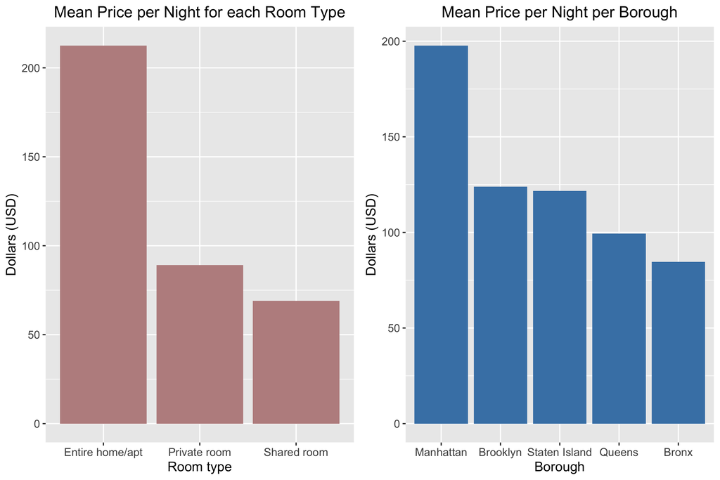

Figure 3. Mean New York Airbnb prices per night based by room type and neighbourhood group in 2019

The mean price per night per night based by room type is as we would have expected, asprices of entire home/apts are higher than private room, followed by shared accomodations.

From the different neighbourhoods, Manhattan is the most expensive, while the Bronx is the cheapest. We expect that neighbourhood group and type of room will be important features in predicting price.

# Our chosen models, metric and why

For our prediction, we have chosen Random Forest, XGBoost, and LightGBM as our models; also, we have picked mean absolute error as our metric and average ensembling as our final prediction. We have decided to pick only ensemble tree-based algorithms because they generally have better predictive performances than other regressors, such as linear regression. Furthermore, the feature, neighbourhood, has over 200 categories, and the only models that can process it with labels are tree-based. Otherwise, we would have to encode it and hence face high cardinality problems, which cannot be handled well by linear regression without further work such as feature selection adn regularization. Moreover, based on our exploratory data analysis, we have decent confidence that tree-based models can figure out prices based on the existing features. The primary value of our models is to provide early Airbnb users with reasonable prices on their listings so that they can get them up and running quickly and effectively. To maximize this value, we average the model predictions as an ensemble for the final predicted prices. For the same reason, we use mean absolute error as our performance metric instead of mean squared error because we want to optimize more for median than mean. Mean is more impacted by outliers than the median, and we think aiming for median rather than mean will produce more of a reasonable price for potential customers, efficiently paving the way to the new hosts’ first bookings.

# Our modelling result

We built three models, Random Forest, LightGBM, and XGBoost, and averaged their predictions to produce the final productions. We derived all models with some degree of hyperparameter tuning. The Random Forest and XGBoost regressors both took considerably longer to train than the LightGBM regressor, and that is why we limited their combinations of hyperparameters for tuning due to our time constraint.

|  | train_mean_absolute_error | test_mean_absolute_error |
| --- | --- | --- |
| Median Null Model | 84.32 | 83.20 |
| Random Forest | 46.71 | 65.35 |
| XGBoost | 53.08 | 65.45 |
| LightGBM | 64.05 | 65.79 |
| Average Ensembling | 53.27 | 63.94 |

Table 1. Mean Absolute Errors

Even though the models have imbalanced hyperparameter tuning, they have comparable results and are all an obvious upgrade over the median null model. Moreover, the ensemble has a decent performance improvement over the base models.

Let us look at the feature importances of different models.

|  | Random.Forest | XGBoost | LightGBM |
| --- | --- | --- | --- |
| neighbourhood_group | 0.004 | 0.095 | 0.003 |
| neighbourhood | 0.078 | 0.085 | 0.056 |
| latitude | 0.171 | 0.080 | 0.156 |
| longitude | 0.289 | 0.284 | 0.151 |
| room_type | 0.127 | 0.176 | 0.043 |
| minimum_nights | 0.072 | 0.054 | 0.181 |
| number_of_reviews | 0.027 | 0.044 | 0.062 |
| reviews_per_month | 0.045 | 0.042 | 0.068 |
| calculated_host_listings_count | 0.086 | 0.097 | 0.130 |
| availability_365 | 0.101 | 0.043 | 0.150 |

Table 2. Feature Importance

Let us look at the ensemble residuals on the test set and their distribution.

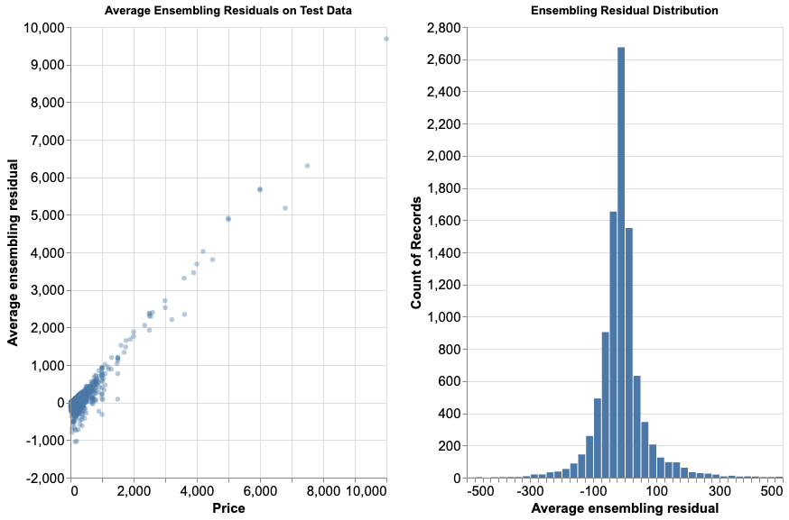

Figure 4. Model results

The residuals look to follow a normal distribution with a few big residuals spread along the high prices. We do not quite care about those big residuals over high prices because we intend our model to estimate the median. In particular, we do not want our model to be affected or swayed by high prices by too much since pulling the predictions towards that direction will hinder the listings’ ability to get bookings quickly and hence discourage new hosts from maintaining those listings. In conclusion, we believe our ensemble has done its job effectively.

# Limitations

Our project has a few limitations. First, the data we have does not capture the season and months of the year. There could be a high correlation between the prices and the season of the year. In particular seasons and holidays, we can expect tourist inflows to be much higher than normal thereby inflating the listing prices. As well, the prices of Airbnb listings fluctuate throughout the year, which is not captured and limits us from probing into this further. Finally, a rating feature would have helped our models to predict the prices better. In the dataset we are using, we do have reviews but it would require us to do sentiment analysis on each review to get a pulse of how the Airbnb listing compares to others.

There are some limitations to our models as well. Due to our time constraint and long training time with random forest as well as xgboost, we could not cover a more extended range of hyperparameters, which could result in better models. Also, since interpretation is not an emphasis in our result, we could go for a more complicated but powerful ensembling technique, such as stacking. Moreover, we did not create any new feature which could potentially improve predictions. For instance, we could turn the last_review feature into a new feature for days since the last review.

# Potential future improvements

If this project were to continue, we had a few upgrades in mind in terms of data analysis and modeling. Regarding data analysis, we would want to look at some new features we can generate, such as days before the last review and whether a listing has low availability. We will explore whether they have distinct patterns on prices and form our expectations about their respective importances. We could potentially take them into account for our models and explore other ensembling techniques, such as stacking, to see if we could arrive at more accurate predictions.

# References

Auguie, Baptiste. 2015. *GridExtra: Miscellaneous Functions for "Grid" Graphics*. http://CRAN.R-project.org/package=gridExtra.

Chandra, Rakesh Vidya, and Bala Subrahmanyam Varanasi. 2015. *Python Requests Essentials*. Packt Publishing Ltd.

Chen, Tianqi, and Carlos Guestrin. 2016. “XGBoost: A Scalable Tree Boosting System.” In *Proceedings of the 22nd Acm Sigkdd International Conference on Knowledge Discovery and Data Mining*, 785–94. KDD ’16. New York, NY, USA: ACM. https://doi.org/10.1145/2939672.2939785.

de Jonge, Edwin. 2018. *Docopt: Command-Line Interface Specification Language*. https://CRAN.R-project.org/package=docopt.

“Get the Data - Inside Airbnb. Adding Data to the Debate.” n.d. http://insideairbnb.com/get-the-data.html.

Ke, Guolin, Qi Meng, Thomas Finley, Taifeng Wang, Wei Chen, Weidong Ma, Qiwei Ye, and Tie-Yan Liu. 2017. “LightGBM: A Highly Efficient Gradient Boosting Decision Tree.” In *Advances in Neural Information Processing Systems 30*, edited by I. Guyon, U. V. Luxburg, S. Bengio, H. Wallach, R. Fergus, S. Vishwanathan, and R. Garnett, 3146–54. Curran Associates, Inc. http://papers.nips.cc/paper/6907-lightgbm-a-highly-efficient-gradient-boosting-decision-tree.pdf.

Keleshev, Vladimir. 2014. *Docopt: Command-Line Interface Description Language*. https://github.com/docopt/docopt.

———. 2019. *Schema: Validating Python Data Structures*. https://github.com/keleshev/schema.

Mcgeehan, Patrick. 2019a. “N.Y. Draws a Record 65 Million Tourists (in Spite of Trump’s Trade War, Many Were Chinese).” *The New York Times*. The New York Times. https://www.nytimes.com/2019/01/16/nyregion/nyc-tourism-record.html.

———. 2019b. “N.Y.C. Is on Pace to Draw a Record 67 Million Tourists This Year.” *The New York Times*. The New York Times. https://www.nytimes.com/2019/08/19/nyregion/nyc-tourism.html.

McKinney, Wes. 2010. “Data Structures for Statistical Computing in Python.” In *Proceedings of the 9th Python in Science Conference*, edited by Stéfan van der Walt and Jarrod Millman, 51–56.

Muthukadan, Baiju. 2019. *Selenium with Python*. https://github.com/baijum/selenium-python.

Oliphant, Travis E. 2006. *A Guide to Numpy*. Vol. 1. Trelgol Publishing USA.

Pedregosa, F., G. Varoquaux, A. Gramfort, V. Michel, B. Thirion, O. Grisel, M. Blondel, et al. 2011. “Scikit-Learn: Machine Learning in Python.” *Journal of Machine Learning Research* 12: 2825–30.

R Core Team. 2019. *R: A Language and Environment for Statistical Computing*. Vienna, Austria: R Foundation for Statistical Computing. https://www.R-project.org/.

Sherwood, Harriet. 2019. “How Airbnb Took over the World.” *The Guardian*. Guardian News; Media. https://www.theguardian.com/technology/2019/may/05/airbnb-homelessness-renting-housing-accommodation-social-policy-cities-travel-leisure.

Sievert, Jacob VanderPlas AND Brian E. Granger AND Jeffrey Heer AND Dominik Moritz AND Kanit Wongsuphasawat AND Arvind Satyanarayan AND Eitan Lees AND Ilia Timofeev AND Ben Welsh AND Scott. 2018. “Altair: Interactive Statistical Visualizations for Python.” *The Journal of Open Source Software* 3 (32). http://idl.cs.washington.edu/papers/altair.

Urbanek, Simon. 2013. *Png: Read and Write Png Images*. https://CRAN.R-project.org/package=png.

Van Rossum, Guido, and Fred L. Drake. 2009. *Python 3 Reference Manual*. Scotts Valley, CA: CreateSpace.

Wickham, Hadley. 2007. “Reshaping Data with the reshape Package.” *Journal of Statistical Software* 21 (12): 1–20. http://www.jstatsoft.org/v21/i12/.

———. 2017. *Tidyverse: Easily Install and Load the ’Tidyverse’*. https://CRAN.R-project.org/package=tidyverse.

Xie, Yihui. 2014. “Knitr: A Comprehensive Tool for Reproducible Research in R.” In *Implementing Reproducible Computational Research*, edited by Victoria Stodden, Friedrich Leisch, and Roger D. Peng. Chapman; Hall/CRC. http://www.crcpress.com/product/isbn/9781466561595.

Xie, Yihui, J.J. Allaire, and Garrett Grolemund. 2018. *R Markdown: The Definitive Guide*. Boca Raton, Florida: Chapman; Hall/CRC. https://bookdown.org/yihui/rmarkdown.

Zhu, Hao. 2019. *KableExtra: Construct Complex Table with ’Kable’ and Pipe Syntax*. https://CRAN.R-project.org/package=kableExtra.